# Covid19 - Simulación para el Norte Antioquia

Osmar Loaiza

5 de abril de 2020

## Introducción

En este documento se presentan simulaciones que presentan un escenario preiliminar del comportamiento posible de la infección por Coronavirus en Antioquia y sus municipios del norte.

La epidemia que ha generado la infección producida por el Coronavirus (COVID19) representa un desafío para el sistema de salud pública Colombiano. Sin embargo, es escasa la información producida por los órganos públicos colombianos, o en su defecto es escasa la información puesta a disposición del público a cerca de los modelos epidemiológicos y estadísicos con los cuales se están generando las proyecciones a nivel del gobierno central para informar la posible evolución de la epidemia.

En los munipios pequeños, donde no se cuenta con la capacidad técnica o administrativa para generar el tipo de información que se requiere para no navegar a ciegas en este escenario de incertidumbre, la escases de información sobre la posible evolución de la epidemia añade al escenario de incertidumbre que enfrentan sus administraciones municipales y su población acerca del curso de la epidemia.

Acá se presenta una simulación basada en el modelo epidemiológico SIR (Susceptibles-Infected-Recovered) para trazar un posible escenario de evolución de la epidemia en algunos municipios de Antioquia.

Sin ser epidemiólogo, pongo estas estimaciones a disposición como cuota inicial para iniciar el debate acerca del posible curso de la infección por COVID-19 más allá de las principales ciudades del país. En cierta medida, esta es una labor riesgosa, porque idealmente serían los organismos de salud del nivel nacional o departamental, o en su defecto la comunidad científica especializada en las áreas de salud pública y epidemiología, quienes deberían estar al frente de esta tarea.

Sin embargo, me justifico en este emprendimiento en la medida en que con la información disponible para Colombia, he obtenido estimaciones razonables del parámetro de contagio R0. Este parámetro mide el potencial de infecciones secundarias que puede generar un individuo poseedor del virus. Mis estimaciones de R0 con base en el modelo SIR a partir de los datos de contagio puestos a disposicición por el Instituto Nacional de Salud (INS) Colombiano, están en línea con la literatura internacional en el tema, la cual ubica el paráemtro R0 para el COVID-19 en un rango entre 2 y 2.5, como lo recogen la [Organización Mundial de la Salud](https://www.who.int/docs/default-source/coronaviruse/who-china-joint-mission-on-covid-19-final-report.pdf) o [NCBI en EEUU](https://www.ncbi.nlm.nih.gov/books/NBK554776/)

Finalmente, es menester que este documento refleja exclusivamente mi puntos de vista personales, y en ningún caso representan los puntos de vista de ninguna organización. Asimismo, quedo abierto a posibles colaboraciones con profesionales de la epidemiología o la estadística para refinar los resultados aquí presentados.

## Metodología

Se pretende simular el comportamiento de los contagios por COVID-19 en Colombia y especialmente en los municipios del norte de Antioquia mediante el uso del modelo epidemiológico SIR. El modelo SIR divide la población en tres categorías: Susceptibles, Infectados, y Recuperados. La evolución del número de personas en cada categoría es modelado mediante tres ecuaciones diferenciales, correspondientes a los tres grupos considerados. La dinámica del comportamiento de los tres grupos es regida por la tasa de recuperación y la tasa de contagios.[^1] El parámetro R0 es el cociente entre estas dos tasas. Se remite al lector interesado a [Bjørnstad (2018)](https://link.springer.com/book/10.1007%2F978-3-319-97487-3)

Hay que anotar que la calibración del modelo SIR se hace utilizando la información para Colombia, y no la información específica para Antiquia. Esto se debe a que en el reporte de contagios en Antioquia se presentan discontinuidades en las pimeras semanas de reporte (es decir, transcurren varios días entre el reporte de nuevos casos de infección por COVID-19). En la medida en que aumente la información reportada para el departamento esta dificultad evantualmente se podrá subsanar posteriormente.

Por tanto, con base en la información publicada por el INS para Colombia se calibran las tasas de recuperación y de contagios, de tal manera que el modelo SIR tenga un alto grado de concordancia con los datos.

Esto se logra minimizando una función de pérdida cuadrática entre el número *observado de infectados* y el número *estimado de infectados*. Por tanto, se eligen los valores de las tasas de recuperación y contagio que minimizan la discrepancia entre los datos y la predicción arrojada por el modelo SIR.[^2]

Como población contagiada se toman los casos reportados como *relacionados* o como *en estudio* por el INS. Se descartan los casos *importados*. Los casos clasificado como imporatdos no son infecciones ocurridas en el país. Por tanto, la dinámica de contagio que conduce a estos casos es ajena a la dinámica local. Por el contrario, los casos marcados como relacionados manifiestan la dinámica local de propagación de la infección mediante contagio en Colombia. Los casos *en estudio* se asumen como casos de contagio. Es decir, el INS desconoce la cadena de contagio que da lugar a estas infecciones, pero se asume que este desconomicimiento señala que la infección ha alcanzado una magnitud tal que el contagio comuntario del virus ha alcanzado una alta difusión de la infección. De esta manera, en la actual coyuntura la infección por COVID-19 ha desbordado la capacidad de las autoridades sanitarias para hacer seguimiento a las cadenbas de contagio.

En consistencia con lo anterior, acá se toma como el día 1 de la epidemia aquella fecha donde se reporta el primer caso por contagio. Esto corresponde al día 11 de Marzo de 2020. Sin embargo, la primera infección registrada corresponde al 6 de Marzo del mismo año, pero este es un caso importado.

Finalmente, acá se toma como el pico de la epidemia aquel momento en el tiempo en el cual la simulación arroja el mayor número de casos activos. Es decir, donde la diferencia entre *infectados* y *recuperados* es máxima.

Por tanto, la difinición de pico de la epidemia que acá se usa puede diferir de la generalmente utilizada en otros estudios, donde este corresponde al momento en el tiempo donde se tiene el mayor número acumulado de infectados.

## Resultados

### Calibración del Modelo SIR para Colombia

Utilizando los datos publicados por el INS al corte del 4 de abril, se estima para actualmente para Colombia un R0 de 2.0288404, siendo la tasa de contagio y la tasa de recuperación 0.6700685 y 0.3302717, respectivamente. Por tanto, se está claramente en una fase de expansión de la infección viral, a pesar del consenso entorno de que los datos disponibles casi seguramente subestiman la verdadera cantidad de contagios.

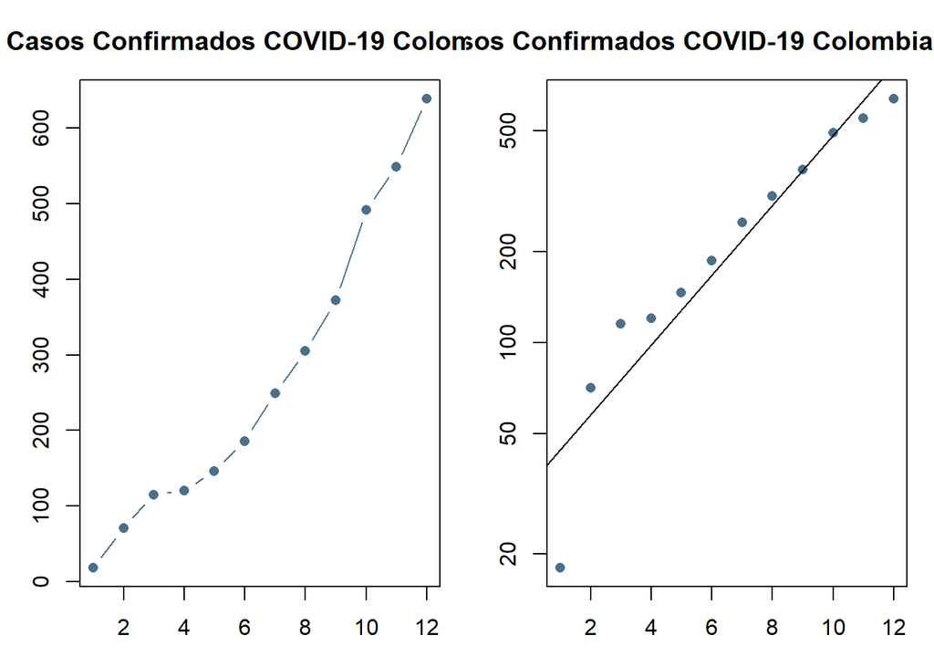

Es clara la tendencia creciente de la epidema actualmente.

#### Simulación de la dinámica de la infección para Colombia

En el siguiente gráfico se simula la evolución de la epidemia para Colombia según la calibración anteriormente descrita del modelo SIR

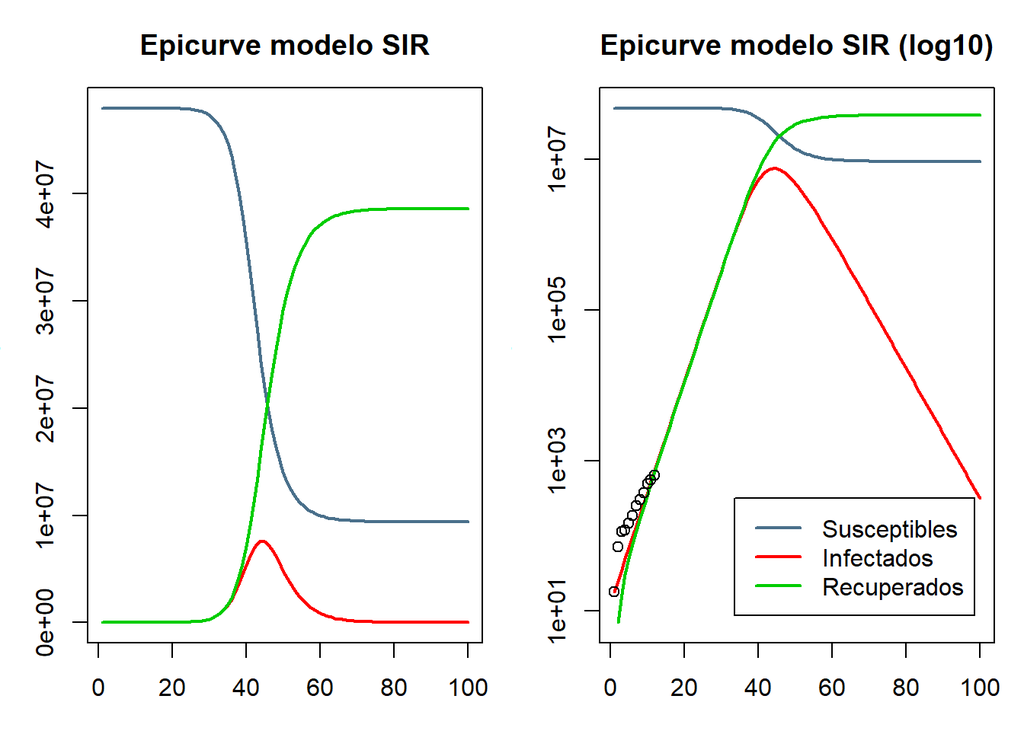

Dada la dinámica actual de la infección en Colombia el modelo SIR anticiparía en el pico de casos activos por COVID las siguientes cifras de infecciones y recuperados:

Pico Epidemia - Colombia

[output not shown]

### Simulaión para Antioquia

Según la simulación para Antioquia se tendría la siguiente evolución:

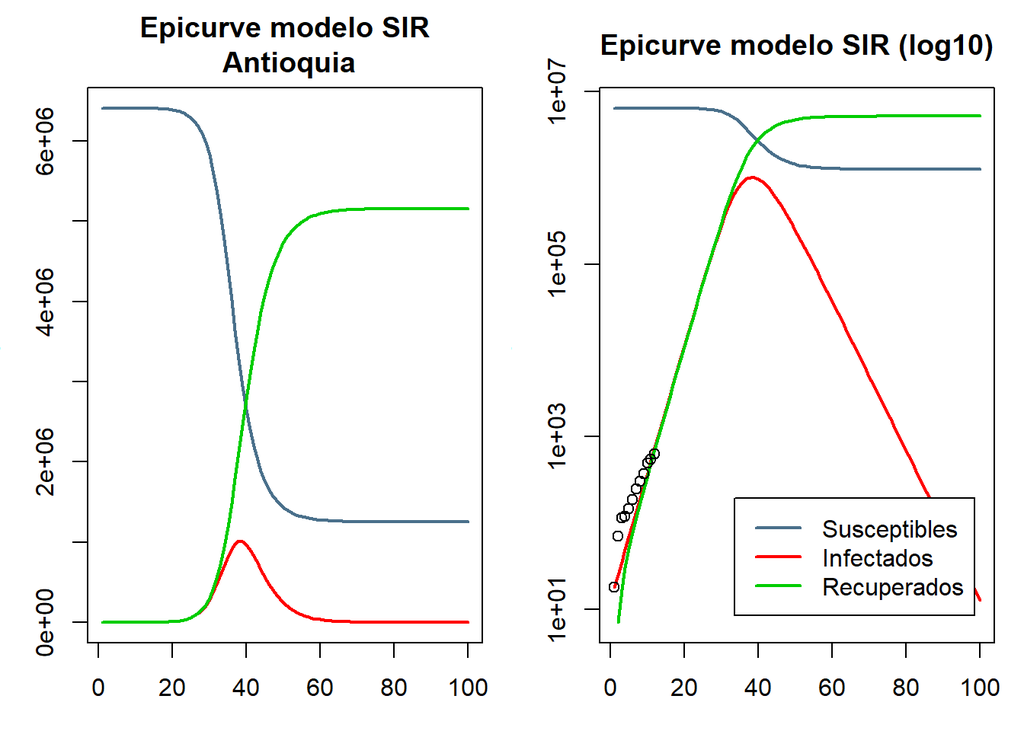

En el pico de la epidemia, dado por aquella circinstancia donde el número de infectados es alto en relación al número de recuperados, se tienen las siguientes cifras:

```r
knitr::kable(tab,caption='Pico Epidemia Antioquia')
```

Pico Epidemia Antioquia

[output not shown]

### Simulación para municipios del Norte de Antioquia

Finalmente, en esta sección se muestra la dinámica simulada de la epidemia para los municipios del Norte de Antioquia. En la actualidad no se reportan infecciones en ninguno de estos municipios, por lo cual los resultados acá reportados corresponden a un posible escenario de evolución de la epidemia por COVID-19 una vez registrado el primer caso en la respectiva municipalidad. La población municipal es tomada del censo de población 2018 del [DANE](https://www.dane.gov.co/index.php/estadisticas-por-tema/demografia-y-poblacion/censo-nacional-de-poblacion-y-vivenda-2018).

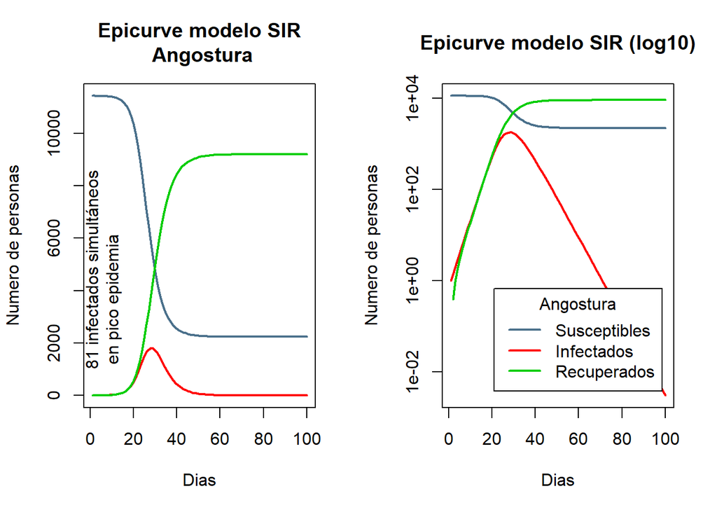

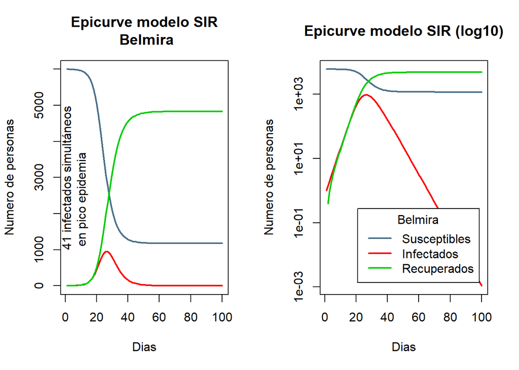

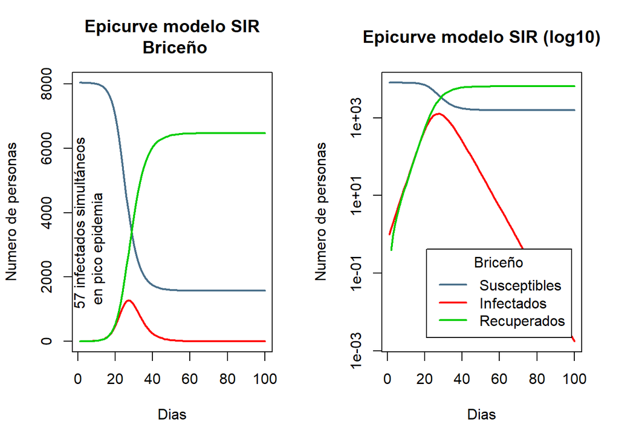

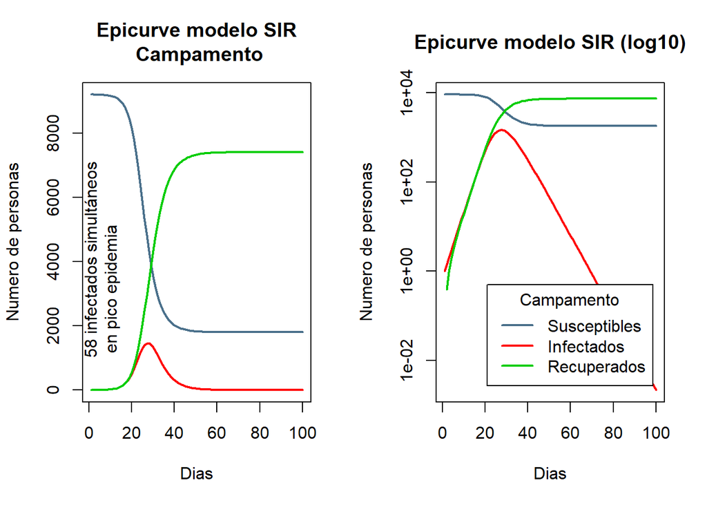

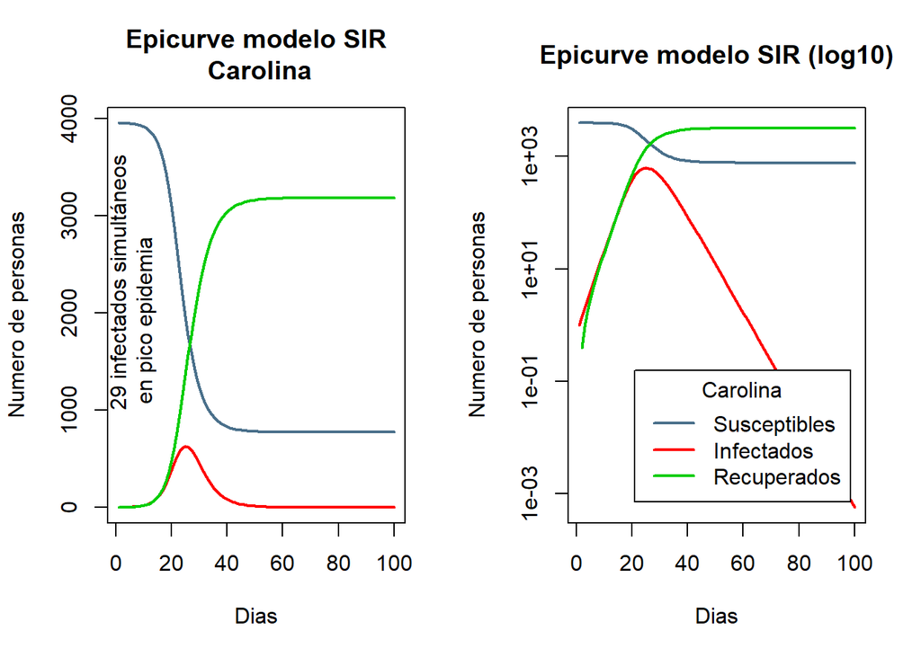

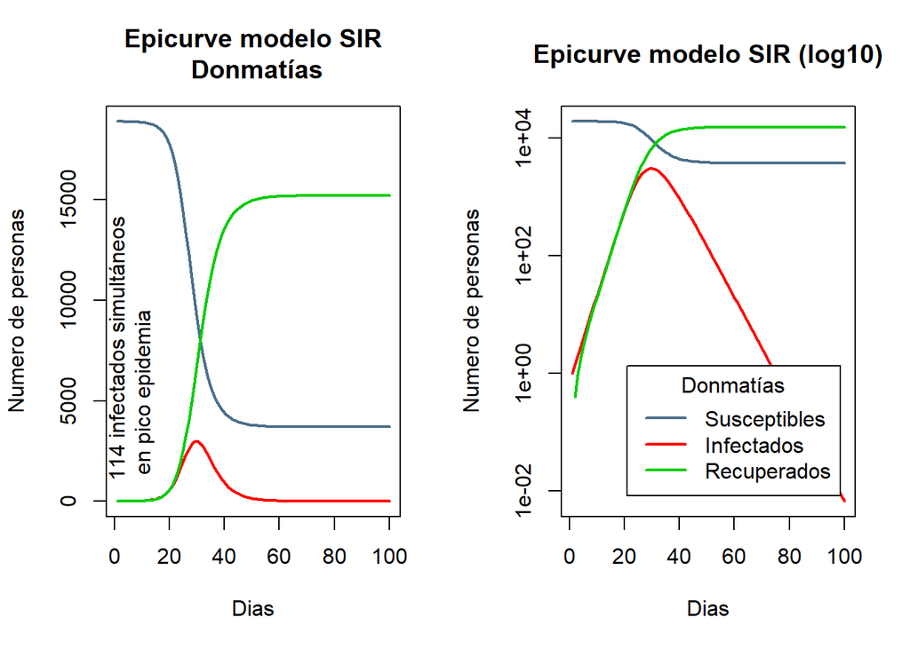

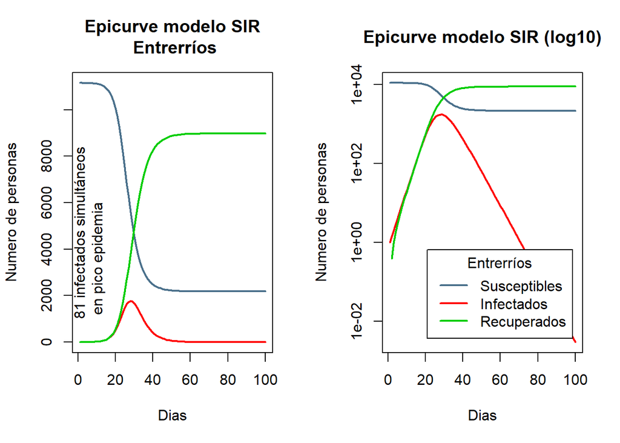

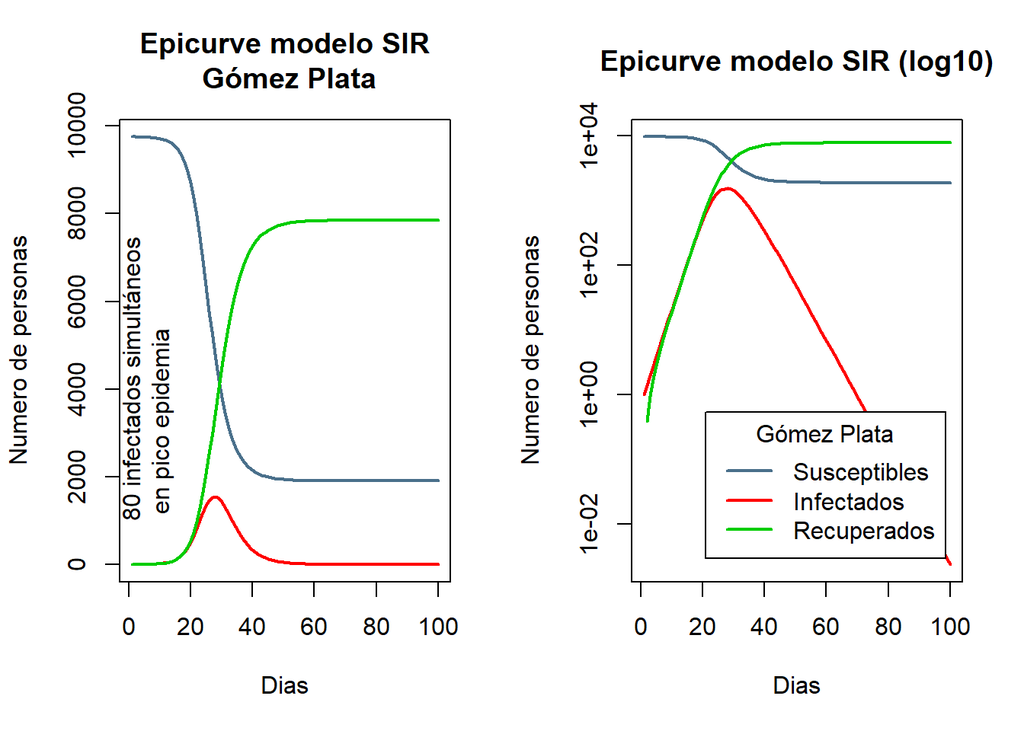

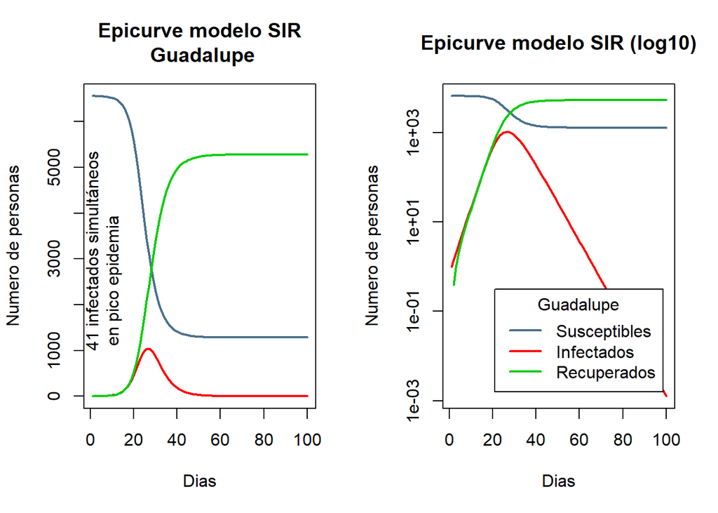

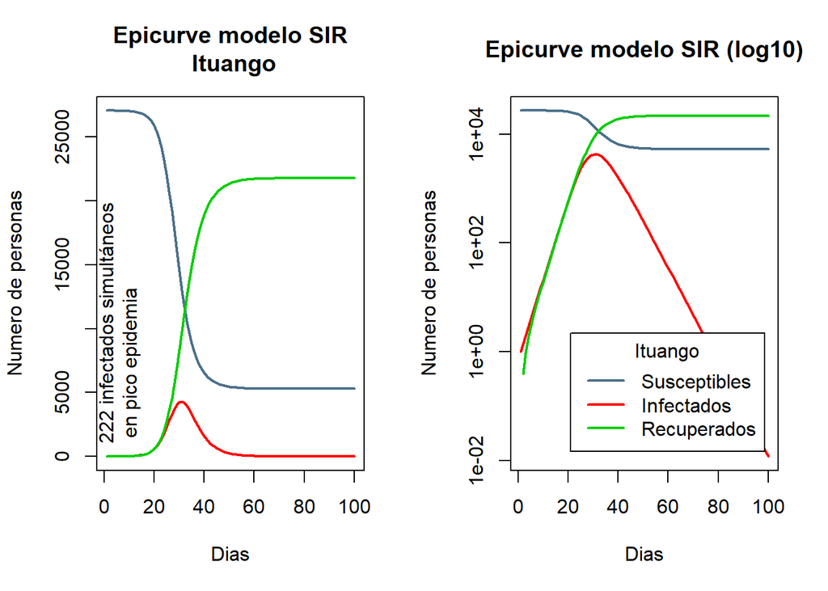

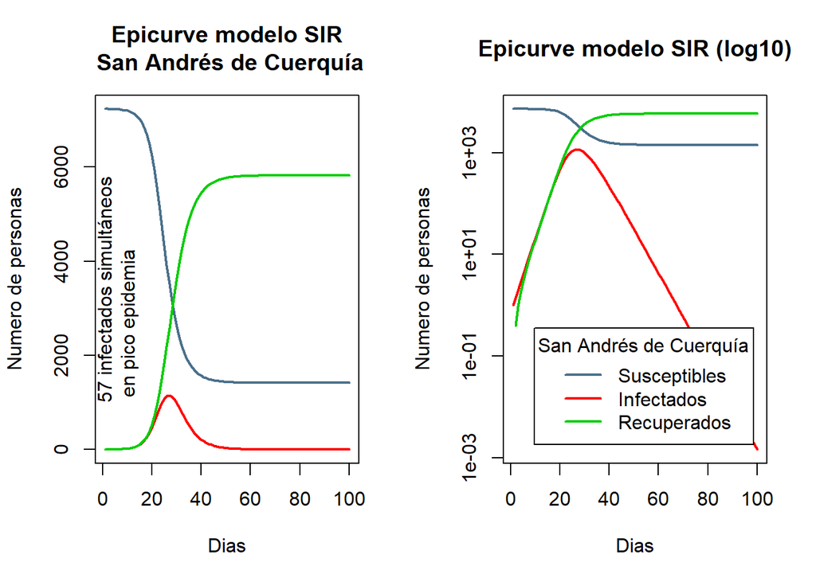

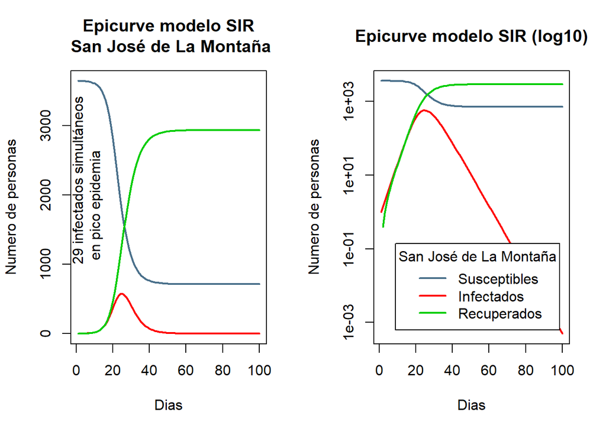

[3 more figures not shown]

[^1]: Siendo más precisos, el parámetro que acá llamamos tasa de contagios es la tasa de contactos multiplicada por la probabilidad de transimisión de la infección [(Bjørnstad, 2018, Capítulo 2)](https://link.springer.com/book/10.1007%2F978-3-319-97487-3)
[^2]: El autor también considera la estimación de un modelo SEIR, pero por el momento es descartado, dado que el R0 calibrado con este modelo arroja valores muy altos (superiores a 6), lo cual está fuera del rango de valores generalmente considerados en la literatura sobre COVID-19